# General Trends and Descriptive Analysis

© Hector Mathonsi

2024-10-19

# Abstract

This report explores the relationships between various factors influencing student performance, using exploratory data analysis (EDA) to identify key trends and correlations. The analysis focuses on variables such as study habits, access to resources, parental involvement, and environmental factors, and how they impact final exam scores. Insights gained from the data will inform recommendations aimed at improving academic outcomes for students.

# Data Source

The dataset was sourced from Kaggle under the CC0 1.0 universal “No Copyright” license. We are free to copy, modify, distribute and perform the work, even for commercial purposes, all without asking permission. Learn more about this license here [here](https://creativecommons.org/publicdomain/zero/1.0/).

URL for data in Kaggle: [Student Performance Factors Dataset](https://www.kaggle.com/datasets/lainguyn123/student-performance-factors)

# Import and View Data

```r
student_data <- read.csv('../data/StudentPerformanceFactors.csv', header = TRUE)
student_data    # Display the dataset
```

| Hours_Studied | Attendance | Parental_Involvement | Access_to_Resources | Extracurricular_Activities | Sleep_Hours | Previous_Scores | Motivation_Level | Internet_Access | Tutoring_Sessions | Family_Income | Teacher_Quality | School_Type | Peer_Influence | Physical_Activity | Learning_Disabilities | Parental_Education_Level | Distance_from_Home | Gender | Exam_Score |
| --- | --- | --- | --- | --- | --- | --- | --- | --- | --- | --- | --- | --- | --- | --- | --- | --- | --- | --- | --- |
| 23 | 84 | Low | High | No | 7 | 73 | Low | Yes | 0 | Low | Medium | Public | Positive | 3 | No | High School | Near | Male | 67 |
| 19 | 64 | Low | Medium | No | 8 | 59 | Low | Yes | 2 | Medium | Medium | Public | Negative | 4 | No | College | Moderate | Female | 61 |
| 24 | 98 | Medium | Medium | Yes | 7 | 91 | Medium | Yes | 2 | Medium | Medium | Public | Neutral | 4 | No | Postgraduate | Near | Male | 74 |
| 29 | 89 | Low | Medium | Yes | 8 | 98 | Medium | Yes | 1 | Medium | Medium | Public | Negative | 4 | No | High School | Moderate | Male | 71 |
| 19 | 92 | Medium | Medium | Yes | 6 | 65 | Medium | Yes | 3 | Medium | High | Public | Neutral | 4 | No | College | Near | Female | 70 |
| 19 | 88 | Medium | Medium | Yes | 8 | 89 | Medium | Yes | 3 | Medium | Medium | Public | Positive | 3 | No | Postgraduate | Near | Male | 71 |
| 29 | 84 | Medium | Low | Yes | 7 | 68 | Low | Yes | 1 | Low | Medium | Private | Neutral | 2 | No | High School | Moderate | Male | 67 |
| 25 | 78 | Low | High | Yes | 6 | 50 | Medium | Yes | 1 | High | High | Public | Negative | 2 | No | High School | Far | Male | 66 |
| 17 | 94 | Medium | High | No | 6 | 80 | High | Yes | 0 | Medium | Low | Private | Neutral | 1 | No | College | Near | Male | 69 |
| 23 | 98 | Medium | Medium | Yes | 8 | 71 | Medium | Yes | 0 | High | High | Public | Positive | 5 | No | High School | Moderate | Male | 72 |

[output cut: 6597 more lines]

### Summary Statistics

```r
summary(student_data)   # Summary statistics for all variables
```

```
 Hours_Studied     Attendance     Parental_Involvement Access_to_Resources
 Min.   : 1.00   Min.   : 60.00   Length:6607          Length:6607
 1st Qu.:16.00   1st Qu.: 70.00   Class :character     Class :character
 Median :20.00   Median : 80.00   Mode  :character     Mode  :character
 Mean   :19.98   Mean   : 79.98
 3rd Qu.:24.00   3rd Qu.: 90.00
 Max.   :44.00   Max.   :100.00
 Extracurricular_Activities  Sleep_Hours     Previous_Scores
 Length:6607                Min.   : 4.000   Min.   : 50.00
 Class :character           1st Qu.: 6.000   1st Qu.: 63.00
 Mode  :character           Median : 7.000   Median : 75.00
                            Mean   : 7.029   Mean   : 75.07
                            3rd Qu.: 8.000   3rd Qu.: 88.00
                            Max.   :10.000   Max.   :100.00
 Motivation_Level   Internet_Access    Tutoring_Sessions Family_Income
 Length:6607        Length:6607        Min.   :0.000     Length:6607
 Class :character   Class :character   1st Qu.:1.000     Class :character
 Mode  :character   Mode  :character   Median :1.000     Mode  :character
                                       Mean   :1.494
                                       3rd Qu.:2.000
                                       Max.   :8.000
 Teacher_Quality    School_Type        Peer_Influence     Physical_Activity
 Length:6607        Length:6607        Length:6607        Min.   :0.000
 Class :character   Class :character   Class :character   1st Qu.:2.000
 Mode  :character   Mode  :character   Mode  :character   Median :3.000
                                                          Mean   :2.968
                                                          3rd Qu.:4.000
                                                          Max.   :6.000
 Learning_Disabilities Parental_Education_Level Distance_from_Home
 Length:6607           Length:6607              Length:6607
 Class :character      Class :character         Class :character
 Mode  :character      Mode  :character         Mode  :character



    Gender            Exam_Score
 Length:6607        Min.   : 55.00
 Class :character   1st Qu.: 65.00
 Mode  :character   Median : 67.00
                    Mean   : 67.24
                    3rd Qu.: 69.00
                    Max.   :101.00
```

```r
head(student_data)      # Display the first few rows of the dataset
```

|  | Hours_Studied | Attendance | Parental_Involvement | Access_to_Resources | Extracurricular_Activities | Sleep_Hours | Previous_Scores | Motivation_Level | Internet_Access | Tutoring_Sessions | Family_Income | Teacher_Quality | School_Type | Peer_Influence | Physical_Activity | Learning_Disabilities | Parental_Education_Level | Distance_from_Home | Gender | Exam_Score |
| --- | --- | --- | --- | --- | --- | --- | --- | --- | --- | --- | --- | --- | --- | --- | --- | --- | --- | --- | --- | --- |
| 1 | 23 | 84 | Low | High | No | 7 | 73 | Low | Yes | 0 | Low | Medium | Public | Positive | 3 | No | High School | Near | Male | 67 |
| 2 | 19 | 64 | Low | Medium | No | 8 | 59 | Low | Yes | 2 | Medium | Medium | Public | Negative | 4 | No | College | Moderate | Female | 61 |
| 3 | 24 | 98 | Medium | Medium | Yes | 7 | 91 | Medium | Yes | 2 | Medium | Medium | Public | Neutral | 4 | No | Postgraduate | Near | Male | 74 |
| 4 | 29 | 89 | Low | Medium | Yes | 8 | 98 | Medium | Yes | 1 | Medium | Medium | Public | Negative | 4 | No | High School | Moderate | Male | 71 |
| 5 | 19 | 92 | Medium | Medium | Yes | 6 | 65 | Medium | Yes | 3 | Medium | High | Public | Neutral | 4 | No | College | Near | Female | 70 |
| 6 | 19 | 88 | Medium | Medium | Yes | 8 | 89 | Medium | Yes | 3 | Medium | Medium | Public | Positive | 3 | No | Postgraduate | Near | Male | 71 |

```r
str(student_data)       # Structure of the dataset
```

```
'data.frame':   6607 obs. of  20 variables:
 $ Hours_Studied             : int  23 19 24 29 19 19 29 25 17 23 ...
 $ Attendance                : int  84 64 98 89 92 88 84 78 94 98 ...
 $ Parental_Involvement      : chr  "Low" "Low" "Medium" "Low" ...
 $ Access_to_Resources       : chr  "High" "Medium" "Medium" "Medium" ...
 $ Extracurricular_Activities: chr  "No" "No" "Yes" "Yes" ...
 $ Sleep_Hours               : int  7 8 7 8 6 8 7 6 6 8 ...
 $ Previous_Scores           : int  73 59 91 98 65 89 68 50 80 71 ...
 $ Motivation_Level          : chr  "Low" "Low" "Medium" "Medium" ...
 $ Internet_Access           : chr  "Yes" "Yes" "Yes" "Yes" ...
 $ Tutoring_Sessions         : int  0 2 2 1 3 3 1 1 0 0 ...
 $ Family_Income             : chr  "Low" "Medium" "Medium" "Medium" ...
 $ Teacher_Quality           : chr  "Medium" "Medium" "Medium" "Medium" ...
 $ School_Type               : chr  "Public" "Public" "Public" "Public" ...
 $ Peer_Influence            : chr  "Positive" "Negative" "Neutral" "Negative" ...
 $ Physical_Activity         : int  3 4 4 4 4 3 2 2 1 5 ...
 $ Learning_Disabilities     : chr  "No" "No" "No" "No" ...
 $ Parental_Education_Level  : chr  "High School" "College" "Postgraduate" "High School" ...
 $ Distance_from_Home        : chr  "Near" "Moderate" "Near" "Moderate" ...
 $ Gender                    : chr  "Male" "Female" "Male" "Male" ...
 $ Exam_Score                : int  67 61 74 71 70 71 67 66 69 72 ...
```

```r
sum(is.na(student_data))    # Check for missing values
```

```
[1] 0
```

# Distribution of Final Exam Scores

## Distribution of Final Exam Scores(Without Considering Other Factors)

Here we will explore the distribution of final exam scores among students with without considering other factors. To find our the distribution of final exam scores, we first need to sample the data and plot a histogram.

```r
# Sample the data
set.seed(123)
exam_score_sample <- student_data$Exam_Score[sample(nrow(student_data), 100)]
exam_score_sample
```

```
  [1] 68 66 74 63 71 67 62 74 67 63 64 72 59 63 63 69 68 63 71 70 66 61 68 71 64
 [26] 64 69 73 70 65 72 65 64 70 69 69 62 68 68 71 69 73 73 66 65 65 69 67 68 69
 [51] 67 65 66 61 66 68 70 66 67 68 70 72 75 67 65 69 72 68 66 66 67 64 65 72 67
 [76] 71 69 59 69 69 66 68 63 67 62 63 72 65 65 63 58 67 65 69 71 66 67 65 61 71
```

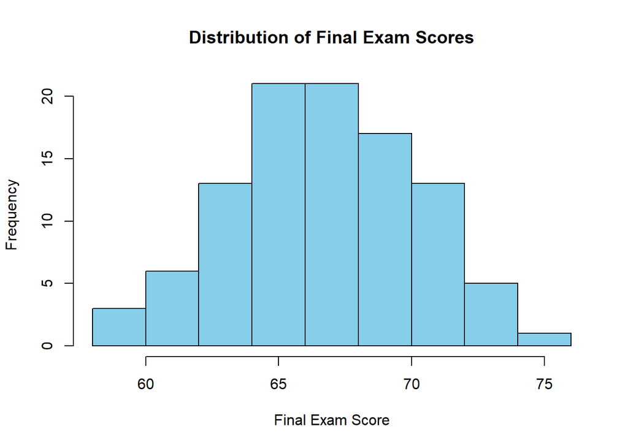

```r
# Plot histogram
hist(exam_score_sample, main = "Distribution of Final Exam Scores", xlab = "Final Exam Score", col = "skyblue", border = "black")
```

From the histogram, we can see that the distribution of final exam scores is approximately normal. We now plot a boxplot to visualize the spread of scores and identify any outliers.

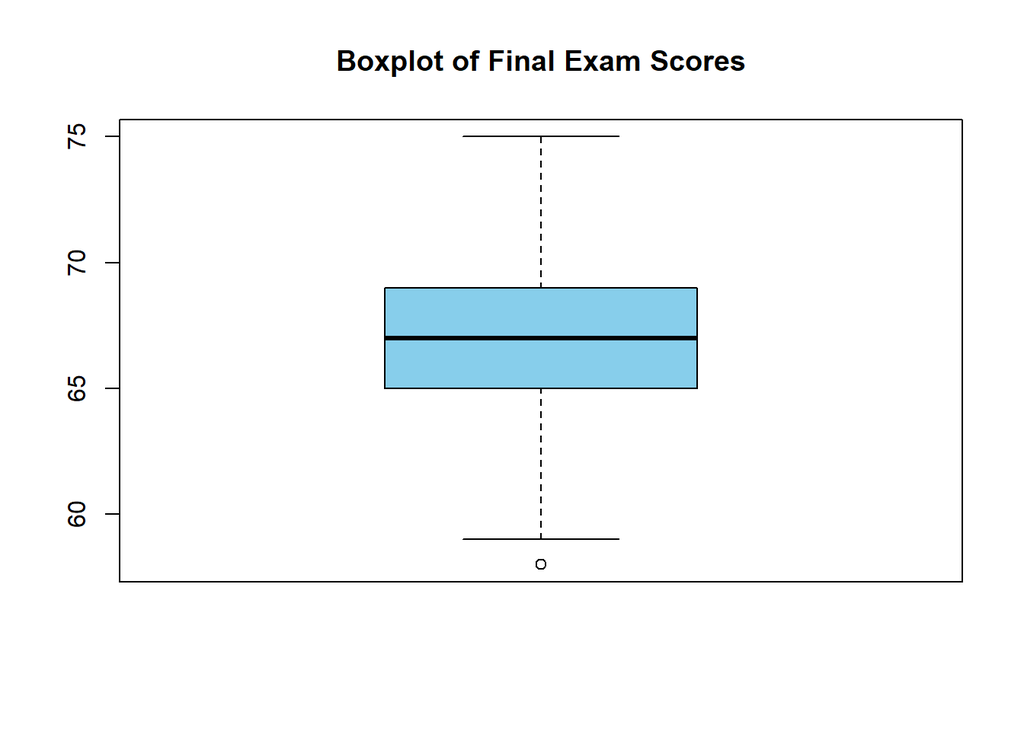

```r
# Boxplot of final exam scores
boxplot(exam_score_sample, main = "Boxplot of Final Exam Scores", col = "skyblue", border = "black")
```

```r
# Shapiro-Wilk test for normality
shapiro.test(exam_score_sample)
```

```
    Shapiro-Wilk normality test

data:  exam_score_sample
W = 0.98776, p-value = 0.4903
```

The Shapiro-Wilk test confirms that the distribution of final exam scores is approximately normal, with a p-value greater than 0.05.

## Distribution of Final Exam Scores (Parental_Involvement Category)

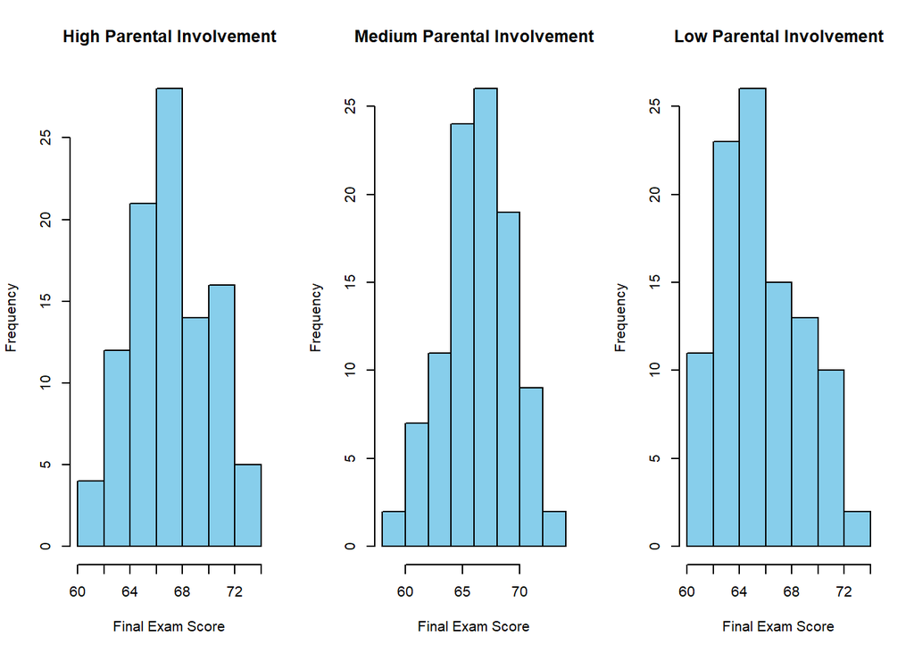

```r
# Sample the data
high_parental_involvement <- student_data$Exam_Score[student_data$Parental_Involvement == "High"][sample(sum(student_data$Parental_Involvement == "High"), 100)]
medium_parental_involvement <- student_data$Exam_Score[student_data$Parental_Involvement == "Medium"][sample(sum(student_data$Parental_Involvement == "Medium"), 100)]
low_parental_involvement <- student_data$Exam_Score[student_data$Parental_Involvement == "Low"][sample(sum(student_data$Parental_Involvement == "Low"), 100)]

# Histogram of final exam scores by parental involvement
par(mfrow = c(1, 3))
hist(high_parental_involvement, main = "High Parental Involvement", xlab = "Final Exam Score", col = "skyblue", border = "black")
hist(medium_parental_involvement, main = "Medium Parental Involvement", xlab = "Final Exam Score", col = "skyblue", border = "black")
hist(low_parental_involvement, main = "Low Parental Involvement", xlab = "Final Exam Score", col = "skyblue", border = "black")
```

The three histograms show the distribution of final exam scores for students with high, medium, and low levels of parental involvement. We can see that the distribution of the scores seems to be similar across all three categories. They seem to follow a normal distribution, with a slight skew towards higher scores for students with high parental involvement. We now use numerical methods to confirm the normality of the distributions.

```r
# Shapiro-Wilk test for normality
shapiro.test(high_parental_involvement)
```

```
    Shapiro-Wilk normality test

data:  high_parental_involvement
W = 0.9794, p-value = 0.1194
```

```r
shapiro.test(medium_parental_involvement)
```

```
    Shapiro-Wilk normality test

data:  medium_parental_involvement
W = 0.98125, p-value = 0.1662
```

```r
shapiro.test(low_parental_involvement)
```

```
    Shapiro-Wilk normality test

data:  low_parental_involvement
W = 0.96994, p-value = 0.02186
```

The Shapiro-Wilk test confirms that the distributions of final exam scores for students with high and medium levels of parental involvement are approximately normal, with p-values greater than 0.05. However, the distribution for students with low parental involvement is slightly skewed, with a p-value less than 0.05.

We now investigate the distribution of final exam scores for students with low parental involvement further. We will now plot a density plot to visualize the distribution more clearly.

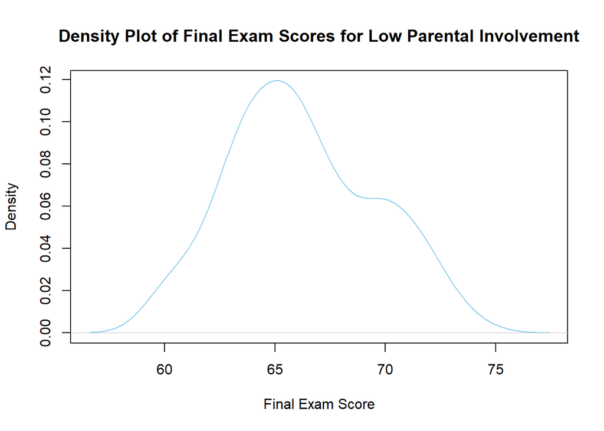

```r
# Density plot of final exam scores for students with low parental involvement
plot(density(low_parental_involvement), main = "Density Plot of Final Exam Scores for Low Parental Involvement", xlab = "Final Exam Score", col = "skyblue")
```

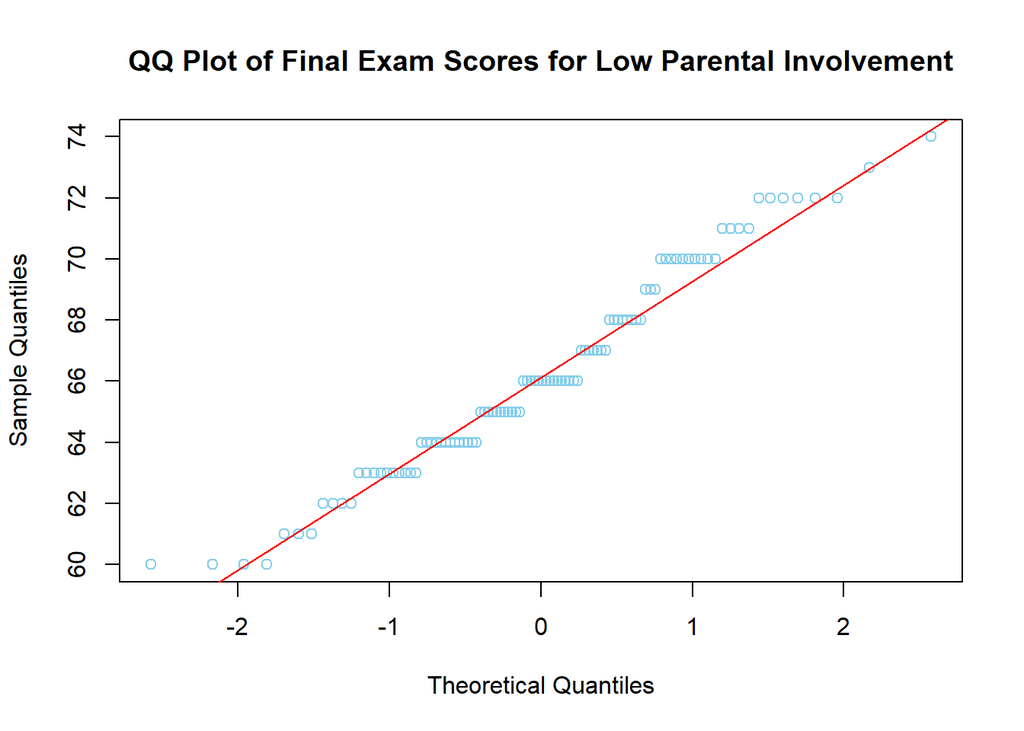

```r
# QQ plot of final exam scores for students with low parental involvement
qqnorm(low_parental_involvement, main = "QQ Plot of Final Exam Scores for Low Parental Involvement", col = "skyblue")
qqline(low_parental_involvement, col = "red")
```

## Distribution of Final Exam Scores (Access_to_Resources Category)

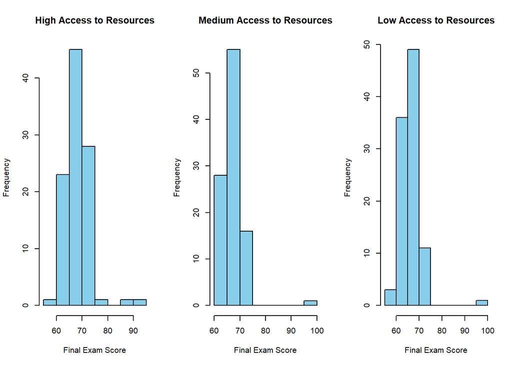

```r
# Sample the data
high_access_to_resources <- student_data$Exam_Score[student_data$Access_to_Resources == "High"][sample(sum(student_data$Access_to_Resources == "High"), 100)]
medium_access_to_resources <- student_data$Exam_Score[student_data$Access_to_Resources == "Medium"][sample(sum(student_data$Access_to_Resources == "Medium"), 100)]
low_access_to_resources <- student_data$Exam_Score[student_data$Access_to_Resources == "Low"][sample(sum(student_data$Access_to_Resources == "Low"), 100)]

# Histogram of final exam scores by access to resources
par(mfrow = c(1, 3))
hist(high_access_to_resources, main = "High Access to Resources", xlab = "Final Exam Score", col = "skyblue", border = "black")
hist(medium_access_to_resources, main = "Medium Access to Resources", xlab = "Final Exam Score", col = "skyblue", border = "black")
hist(low_access_to_resources, main = "Low Access to Resources", xlab = "Final Exam Score", col = "skyblue", border = "black")
```